# Homework 3 Markdown

3b. Make a boxplot showing the variability in sea ice extent every month.

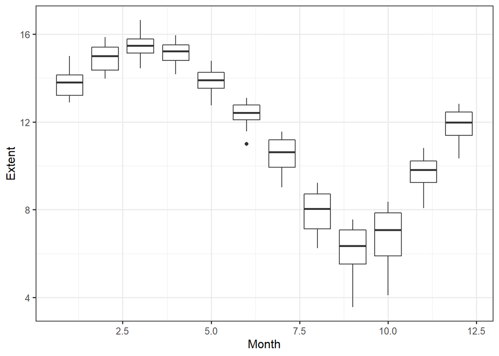

```r
# Put the data into a data frame. Used part of his code from https://gist.github.com/cavedave/c5c2224c8c38661236c1c1ce894fd28f

icedf <- data.frame(Year=c(ice$Year),
                    Month=c(ice$Month),
                    Day=c(ice$Day),
                    Extent=c(ice$Extent),
                    Missing=c(ice$Missing))


pen_plot_base_ice <- ggplot(data = icedf,
                        mapping = aes(x = Month,
                                      y = Extent,
                                      group = Month))


pen_plot_base_ice +
  geom_boxplot()
```

3c. Use dplyr to get the annual minimum sea ice extent. Plot minimum ice by year. What do you observe?

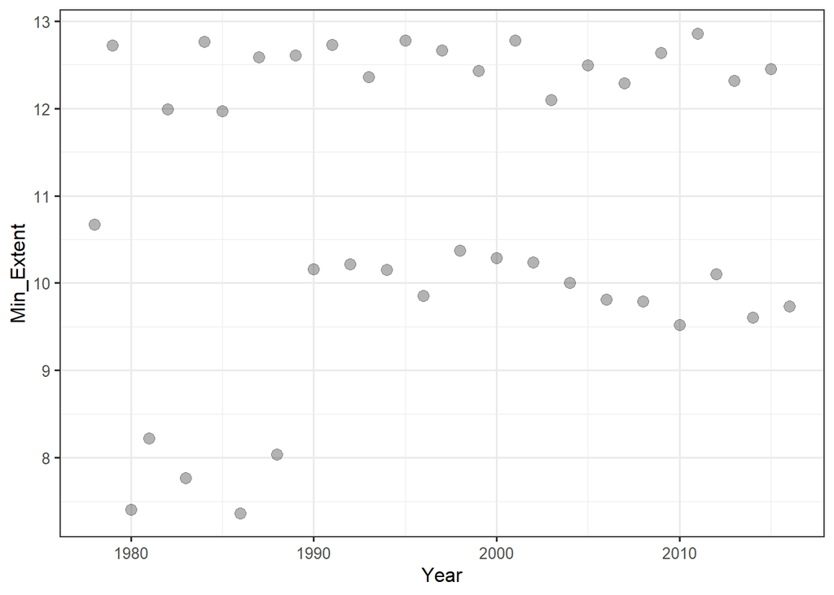

```r
myveccompa <- 1 # A vector has two components that define it
myveccompb <- 2 # These will be adjusted to determine annual mins
myvec <- myveccompa:myveccompb

# This function begins configuring the next vector to
# represent the next year
configure_vector_for_next_year <- function(myveccompa, myveccompb){
  myveccompa <<- myveccompb + 1 #begin configuring the next vector
  myveccompb <<- myveccompb + 6 #to represent the next year
  myvec <- myveccompa:myveccompb
  return(myvec)
}

min1978 <- min(ice$Extent[myvec]) #minimum ice extent 1978
min1979 <- min(ice$Extent[configure_vector_for_next_year(myveccompa, myveccompb)]) #minimum ice extent 1979
min1980 <- min(ice$Extent[configure_vector_for_next_year(myveccompa, myveccompb)]) #minimum ice extent 1980
min1981 <- min(ice$Extent[configure_vector_for_next_year(myveccompa, myveccompb)]) #minimum ice extent 1981
min1982 <- min(ice$Extent[configure_vector_for_next_year(myveccompa, myveccompb)]) #minimum ice extent 1982
min1983 <- min(ice$Extent[configure_vector_for_next_year(myveccompa, myveccompb)]) #minimum ice extent 1983
min1984 <- min(ice$Extent[configure_vector_for_next_year(myveccompa, myveccompb)]) #minimum ice extent 1984
min1985 <- min(ice$Extent[configure_vector_for_next_year(myveccompa, myveccompb)]) #minimum ice extent 1985
min1986 <- min(ice$Extent[configure_vector_for_next_year(myveccompa, myveccompb)]) #minimum ice extent 1986
min1987 <- min(ice$Extent[configure_vector_for_next_year(myveccompa, myveccompb)]) #minimum ice extent 1987
min1988 <- min(ice$Extent[configure_vector_for_next_year(myveccompa, myveccompb)]) #minimum ice extent 1988
min1989 <- min(ice$Extent[configure_vector_for_next_year(myveccompa, myveccompb)]) #minimum ice extent 1989
min1990 <- min(ice$Extent[configure_vector_for_next_year(myveccompa, myveccompb)]) #minimum ice extent 1990
min1991 <- min(ice$Extent[configure_vector_for_next_year(myveccompa, myveccompb)]) #minimum ice extent 1991
min1992 <- min(ice$Extent[configure_vector_for_next_year(myveccompa, myveccompb)]) #minimum ice extent 1992
min1993 <- min(ice$Extent[configure_vector_for_next_year(myveccompa, myveccompb)]) #minimum ice extent 1993
min1994 <- min(ice$Extent[configure_vector_for_next_year(myveccompa, myveccompb)]) #minimum ice extent 1994
min1995 <- min(ice$Extent[configure_vector_for_next_year(myveccompa, myveccompb)]) #minimum ice extent 1995
min1996 <- min(ice$Extent[configure_vector_for_next_year(myveccompa, myveccompb)]) #minimum ice extent 1996
min1997 <- min(ice$Extent[configure_vector_for_next_year(myveccompa, myveccompb)]) #minimum ice extent 1997
min1998 <- min(ice$Extent[configure_vector_for_next_year(myveccompa, myveccompb)]) #minimum ice extent 1998
min1999 <- min(ice$Extent[configure_vector_for_next_year(myveccompa, myveccompb)]) #minimum ice extent 1999
min2000 <- min(ice$Extent[configure_vector_for_next_year(myveccompa, myveccompb)]) #minimum ice extent 2000
min2001 <- min(ice$Extent[configure_vector_for_next_year(myveccompa, myveccompb)]) #minimum ice extent 2001
min2002 <- min(ice$Extent[configure_vector_for_next_year(myveccompa, myveccompb)]) #minimum ice extent 2002
min2003 <- min(ice$Extent[configure_vector_for_next_year(myveccompa, myveccompb)]) #minimum ice extent 2003
min2004 <- min(ice$Extent[configure_vector_for_next_year(myveccompa, myveccompb)]) #minimum ice extent 2004
min2005 <- min(ice$Extent[configure_vector_for_next_year(myveccompa, myveccompb)]) #minimum ice extent 2005
min2006 <- min(ice$Extent[configure_vector_for_next_year(myveccompa, myveccompb)]) #minimum ice extent 2006
min2007 <- min(ice$Extent[configure_vector_for_next_year(myveccompa, myveccompb)]) #minimum ice extent 2007
min2008 <- min(ice$Extent[configure_vector_for_next_year(myveccompa, myveccompb)]) #minimum ice extent 2008
min2009 <- min(ice$Extent[configure_vector_for_next_year(myveccompa, myveccompb)]) #minimum ice extent 2009
min2010 <- min(ice$Extent[configure_vector_for_next_year(myveccompa, myveccompb)]) #minimum ice extent 2010
min2011 <- min(ice$Extent[configure_vector_for_next_year(myveccompa, myveccompb)]) #minimum ice extent 2011
min2012 <- min(ice$Extent[configure_vector_for_next_year(myveccompa, myveccompb)]) #minimum ice extent 2012
min2013 <- min(ice$Extent[configure_vector_for_next_year(myveccompa, myveccompb)]) #minimum ice extent 2013
min2014 <- min(ice$Extent[configure_vector_for_next_year(myveccompa, myveccompb)]) #minimum ice extent 2014
min2015 <- min(ice$Extent[configure_vector_for_next_year(myveccompa, myveccompb)]) #minimum ice extent 2015
min2016 <- min(ice$Extent[configure_vector_for_next_year(myveccompa, myveccompb)]) #minimum ice extent 2016

min_for_all_years <- c(min1978,
           min1979,
           min1980,
           min1981,
           min1982,
           min1983,
           min1984,
           min1985,
           min1986,
           min1987,
           min1988,
           min1989,
           min1990,
           min1991,
           min1992,
           min1993,
           min1994,
           min1995,
           min1996,
           min1997,
           min1998,
           min1999,
           min2000,
           min2001,
           min2002,
           min2003,
           min2004,
           min2005,
           min2006,
           min2007,
           min2008,
           min2009,
           min2010,
           min2011,
           min2012,
           min2013,
           min2014,
           min2015,
           min2016)

year_and_min_extent_df <- data.frame(Year = 1978:2016,
                                     Min_Extent = min_for_all_years)

pen_plot_base <- ggplot(data = year_and_min_extent_df,
                        mapping = aes(x = Year,
                                      y = Min_Extent))

pen_plot_base +
  geom_point(size = 3,
             alpha = 0.3)
```

Due to limited time, I am not sure if the data is sorted uniformly (I saw there were a few issues) in the excel document. Also, I was not sure where or how to use dplyr.However, in the chart that I have, I can observe that minimum sea ice extent is highly variable by year (it also seems to alternate in adjacent years) and it has an increasing trend over the years in the time period.

3d. One thing that’s really cool about faceting is that you can use cut_*() functions on continuos variables to make facets by groups of continuous variables. To see what I mean, try cut_interval(1:10, n = 5) See how it makes five bins of even width? We use cut_interval() or other cut functions with faceting like so facet_wrap(~cut_interval(some_variable)).

```r
#Try cut_interval(1:10, n = 5)
cut_interval(1:10, n = 5)
```

```
##  [1] [1,2.8]   [1,2.8]   (2.8,4.6] (2.8,4.6] (4.6,6.4] (4.6,6.4] (6.4,8.2]
##  [8] (6.4,8.2] (8.2,10]  (8.2,10]
## Levels: [1,2.8] (2.8,4.6] (4.6,6.4] (6.4,8.2] (8.2,10]
```

With the original data, plot sea ice by year, with different lines (oh! What geom will you need for that?) for different months. Then, use facet_wrap and cut_interval(Month, n=4) to split the plot into seasons.

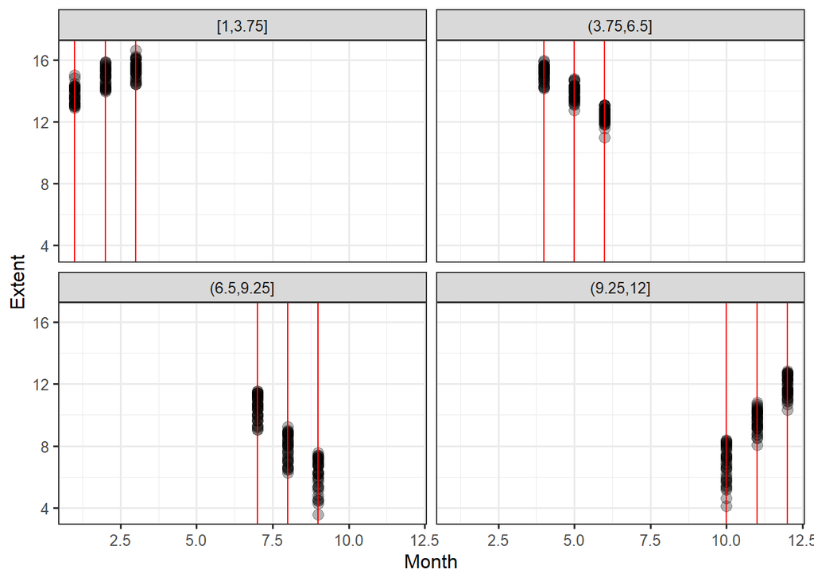

```r
# Original data base, Month versus Extent
pen_plot_base_ice <- ggplot(data = icedf,
                        mapping = aes(x = Month,
                                      y = Extent))

pen_plot_base_ice +
  geom_point(size = 3,
             alpha = 0.3) +
  geom_vline(data=icedf, mapping=aes(xintercept= Month), color= "Red") + # Add vertical lines by month
  facet_wrap(~cut_interval(Month, n = 4)) # Split the plot into seasons
```

3e. Last, make a line plot of sea ice by month with different lines as different years. Gussy it up with colors by year, a different theme, critical values, and whatever other annotations, changes to axes, etc., you think best show the story of this data. For ideas, see the lab, and look at various palettes around. Extra credit for using colorfindr to make a palette.

Due to limited time, this is as far as I came with 3e.

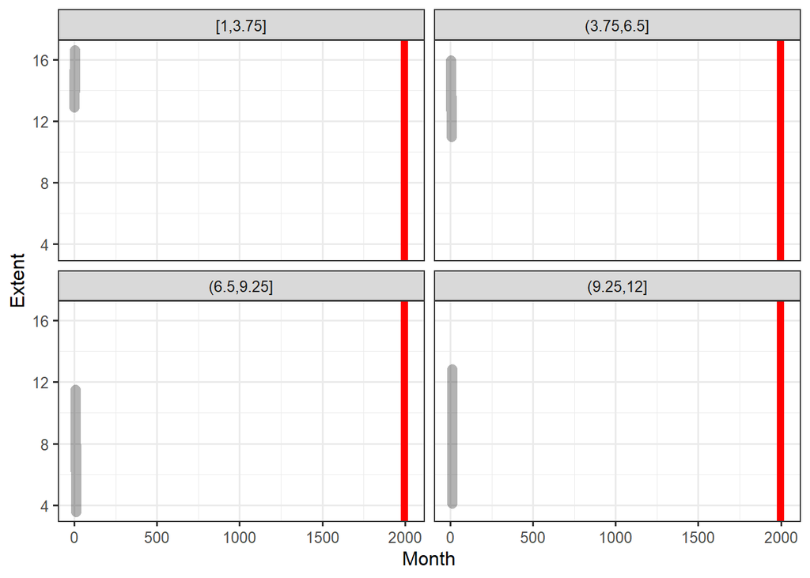

```r
# Original data base, Month versus Extent
pen_plot_base_ice <- ggplot(data = icedf,
                        mapping = aes(x = Month,
                                      y = Extent))

pen_plot_base_ice +
  geom_line(size = 3,
             alpha = 0.3) +
  geom_vline(data=icedf, mapping=aes(xintercept= Year), color= "Red") + # Add vertical lines by month
  facet_wrap(~cut_interval(Month, n = 4)) # Split the plot into seasons
```